# Prueba Técnica -

### Conclusiones del EDA

- Elegimos mantener los features con valores cero y controlamos que no superen el 30% del total de observaciones
- Los outliers estan explicados por ser películas populares o de alta taquilla (Avatar, Titanic, Minions, Jurassic World). Elegimos no eliminarlos del dataset.
- Hicimos feature egineering del año de release, ya que observamos que a medida que pasan los años son mayores las cantidades de votos. No está fuertemente correlacionada, pero causacion no es correlacion.
- Eliminamos algunos features que por sus carácteristicas se comportarian casi como constantes en el modelo -lenguaje, status-
- Se observan valores significativos de correlación en las variables

### Breve Análisis gráfico de una película - Reservoir Dogs

En mi caso, soy fanático de Quentin Tantino, y en especial la película "Perros de la Calle', que fue realizada con muy bajo presupuesto y un reparto espectacular. Analizaremos la misma y como se ubica en cada una de las distribuciones.

```python
# Creamos un dataset de la película para incluirlo en los charts como observación
df_reservoir_dogs = df_movies[df_movies.title =='Reservoir Dogs']
```

```python
df_reservoir_dogs
```

|  | budget | popularity | release_date | revenue | runtime | title | vote_average | vote_count | year |
| --- | --- | --- | --- | --- | --- | --- | --- | --- | --- |
| 4300 | 1200000 | 66.92587 | 1992-09-02 | 14661007 | 99.00000 | Reservoir Dogs | 8.00000 | 3697 | 1992 |

Perros de la calle -Reservoir Dogs- es del año 1992, con una duración de 99 minutos y un presupuesto de 1.2 millones de dolares, bajo para los estándares de holywood. Tiene una calificación promedio de 8 y una popularidad de 66.

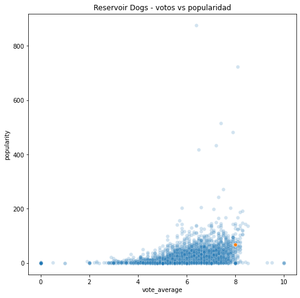

```python
 # Reservoir Dogs en votos vs popularidad
plt.figure(figsize=(8,8))
plt.title('Reservoir Dogs - votos vs popularidad')
sns.scatterplot(data=df_movies,y='popularity',x='vote_average', alpha = 0.2)
plt.ticklabel_format(style='plain')
sns.scatterplot(data=df_reservoir_dogs, y='popularity', x='vote_average');
```

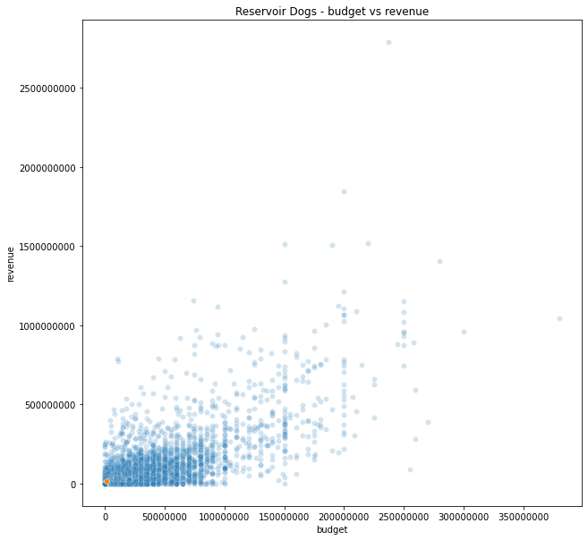

```python
 # Reservoir Dogs en presupuesto vs ingresos
plt.figure(figsize=(10,10))
plt.title('Reservoir Dogs - budget vs revenue')
plt.ticklabel_format(style='plain')
sns.scatterplot(data=df_movies,y='revenue',x='budget', alpha = 0.2)
sns.scatterplot(data=df_reservoir_dogs, y='revenue', x='budget');
```

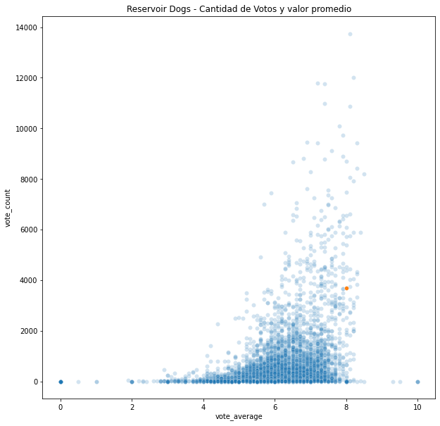

```python
# Reservoir Dogs en votos (cantidad vs promedio)
plt.figure(figsize=(10,10))
plt.title('Reservoir Dogs - Cantidad de Votos y valor promedio')
plt.ticklabel_format(style='plain')
sns.scatterplot(data=df_movies,y='vote_count',x='vote_average', alpha = 0.2)
sns.scatterplot(data=df_reservoir_dogs, y='vote_count', x='vote_average');
```

### Tres conclusiones a partir de los datos observados sobre reservoir dogs

- Es una película con promedio de voto alto, y popularidad media a alta
- Es una película con bajo costo y relativamente pocos ingresos
- Posee una cantidad sustancial de votos con alta calificación

# Modelo de predicción de la popularidad

### Limitación

Atento a la premisa de la prueba técnica en la cual se puede emplear un solo modelo, eligiremos el de Regresión de árboles de decisión, ya que es el que puede traer mejores predicciones con respecto a datasets con outliers.

### Preparar Train - Test sets

```python
df_movies.columns
```

```
Index(['budget', 'popularity', 'release_date', 'revenue', 'runtime', 'title',
       'vote_average', 'vote_count', 'year'],
      dtype='object')
```

```python
# Train y test
X = df_movies[['budget', 'revenue', 'runtime', 'vote_average', 'vote_count', 'year']]
y = df_movies.popularity
X_train, X_test, y_train, y_test = train_test_split(X,y,test_size=0.3,random_state=42)
```

### Regresor con Arboles de Decisión

```python
dt = DecisionTreeRegressor(max_depth=24, min_samples_leaf=4,criterion='mse',random_state=20)
dt.fit(X_train, y_train)
```

```
DecisionTreeRegressor(max_depth=24, min_samples_leaf=4, random_state=20)
```

```python
# Prediciones
y_dt_pred = dt.predict(X_test)

# Métricas
dt_r2 = r2_score(y_test, y_dt_pred)
dt_mae = mean_absolute_error(y_test, y_dt_pred)
print("Arbol Decisión R2: ", dt_r2)
print("Arbol decisión MAE: ", dt_mae)
```

```
Arbol Decisión R2:  0.7433057783975027
Arbol decisión MAE:  6.374375387402447
```

```python
tabla_pred = pd.DataFrame({"Arbol": y_dt_pred,  "Real": y_test})
```

```python
# Predicciones en 10 casos al azar
tabla_pred.sample(10).sort_values('Real')
```

|  | Arbol | Real |
| --- | --- | --- |
| 4070 | 3.30121 | 0.80376 |
| 4084 | 2.46468 | 1.86700 |
| 2969 | 0.45508 | 1.98555 |
| 3662 | 9.27745 | 10.61957 |
| 1129 | 18.63375 | 14.73351 |
| 1504 | 28.52380 | 18.84332 |
| 969 | 22.78044 | 23.07393 |
| 1057 | 18.37724 | 23.23465 |
| 152 | 56.19111 | 56.74798 |
| 220 | 52.29714 | 68.88939 |

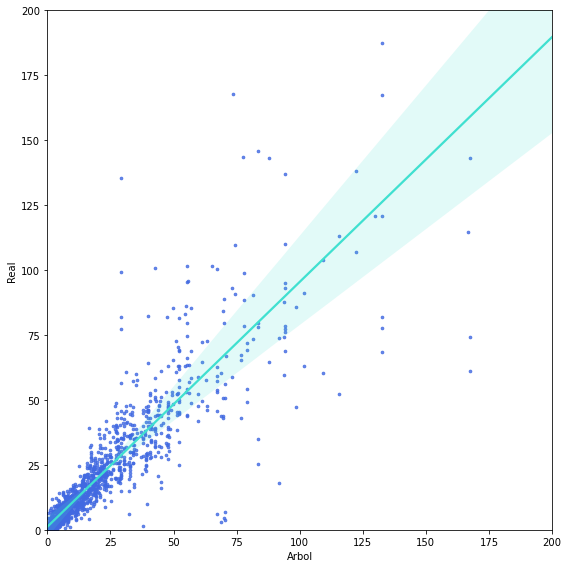

```python
# Visualizacion en scatterplot del precio predecido y actual
fig = plt.figure(figsize=(8,8))
sns.regplot(x = 'Arbol', y = 'Real', data = tabla_pred,
           color = 'royalblue',scatter_kws={"s": 7}, line_kws={"color": "turquoise"})
plt.xlim(0,200)
plt.ylim(0,200)
plt.tight_layout()
plt.show()
```

## Próximos pasos

- Aplicar otros modelos predictivos y comparar los parámetros
- Estudiar variables JSON (actores, director) e incorporarlas a título de ensayo como features para ver si contribuyen al modelo
- Analizar en profundidad los outliers
- Analizar el efecto de las observaciones con valores en 0
- Crear con feature engineering variables que ajusten budget y revenue por inflación (que especialmente fue alta en la era de los presidentes Carter y Reagan)
- Aplicar otros algoritmos de regularizaciones sobre los features
- Pese a ser los árboles de decisión uno de los métodos mas efectivos para conjunto de datos con outliers, correr otros modelos sobre el dataset